# Telecommunications Churn Data

## Scenario: Telecommunications Churn

In the telecommunications industry, customers can choose from multiple service providers and actively switch from one provider to another. Customer “churn” is defined as the percentage of customers who stopped using a provider’s product or service during a certain time frame. In this highly competitive market, some telecommunications industries can experience average annual churn rates as high as 25 percent. Given that it costs 10 times more to acquire a new customer than to retain an existing one, customer retention has now become even more important than customer acquisition.

For many providers, retaining highly profitable customers is the number one business goal. To reduce customer churn, telecommunications companies need to predict which customers are at high risk of churn.

## Information

Full github profile for this project can be seen [Here](https://github.com/TrikerDev/Data-Cleaning-D206). The raw data being used for this analysis can be seen [Here](https://github.com/TrikerDev/Data-Cleaning-D206/blob/main/Telecommunications%20Churn%20Data/churn_raw_data.csv). Data Dictionary for all variables can be seen listed below and [Here](https://github.com/TrikerDev/Data-Cleaning-D206/blob/main/Telecommunications%20Churn%20Data/D206%20Data%20Cleaning%20Churn%20Data%20Consideration%20and%20Dictionary.pdf).

## Data Dictionary:

The data set includes the following information:

• customers who left within the last month (the “Churn” column)

• services that each customer signed up for (phone, multiple lines, internet, online security, online backup, device protection, technical support, and streaming TV and movies)

• customer account information (how long they’ve been a customer, contracts, payment methods, paperless billing, monthly charges, GB usage over a year, etc.)

• customer demographics (gender, age, job, income, etc.)

The data set consists of 10,000 customers and 50 columns/variables:

• CaseOrder: A placeholder variable to preserve the original order of the raw data file

• Customer_id: Unique customer ID

• Interaction, UID: Unique IDs related to customer transactions, technical support, and sign-ups

The following variables represent customer demographic data:

o City: Customer city of residence as listed on the billing statement

o State: Customer state of residence as listed on the billing statement

o County: Customer county of residence as listed on the billing statement

o Zip: Customer zip code of residence as listed on the billing statement

o Lat, Lng: GPS coordinates of customer residence as listed on the billing statement

o Population: Population within a mile radius of customer, based on census data

o Area: Area type (rural, urban, suburban), based on census data

o TimeZone: Time zone of customer residence based on customer’s sign-up information

o Job: Job of the customer (or invoiced person) as reported in sign-up information

o Children: Number of children in customer’s household as reported in sign-up information

o Age: Age of customer as reported in sign-up information

o Education: Highest degree earned by customer as reported in sign-up information

o Employment: Employment status of customer as reported in sign-up information

o Income: Annual income of customer as reported at time of sign-up

o Marital: Marital status of customer as reported in sign-up information

o Gender: Customer self-identification as male, female, or nonbinary

• Churn: Whether the customer discontinued service within the last month (yes, no)

• Outage_sec_perweek: Average number of seconds per week of system outages in the customer’s neighborhood

• Email: Number of emails sent to the customer in the last year (marketing or correspondence)

• Contacts: Number of times customer contacted technical support

• Yearly_equip_failure: The number of times customer’s equipment failed and had to be reset/replaced in the past year

• Techie: Whether the customer considers themselves technically inclined (based on customer questionnaire when they signed up for services) (yes, no)

• Contract: The contract term of the customer (month-to-month, one year, two year)

• Port_modem: Whether the customer has a portable modem (yes, no)

• Tablet: Whether the customer owns a tablet such as iPad, Surface, etc. (yes, no)

• InternetService: Customer’s internet service provider (DSL, fiber optic, None)

• Phone: Whether the customer has a phone service (yes, no)

• Multiple: Whether the customer has multiple lines (yes, no)

• OnlineSecurity: Whether the customer has an online security add-on (yes, no)

• OnlineBackup: Whether the customer has an online backup add-on (yes, no)

• DeviceProtection: Whether the customer has device protection add-on (yes, no)

• TechSupport: Whether the customer has a technical support add-on (yes, no)

• StreamingTV: Whether the customer has streaming TV (yes, no)

• StreamingMovies: Whether the customer has streaming movies (yes, no)

• PaperlessBilling: Whether the customer has paperless billing (yes, no)

• PaymentMethod: The customer’s payment method (electronic check, mailed check, bank (automatic bank transfer), credit card (automatic))

• Tenure: Number of months the customer has stayed with the provider

• MonthlyCharge: The amount charged to the customer monthly. This value reflects an average per customer.

• Bandwidth_GB_Year: The average amount of data used, in GB, in a year by the customer

The following variables represent responses to an eight-question survey asking customers to rate the importance of various factors/surfaces on a scale of 1 to 8 (1 = most important, 8 = least important)

o Item1: Timely response

o Item2: Timely fixes

o Item3: Timely replacements

o Item4: Reliability

o Item5: Options

o Item6: Respectful response

o Item7: Courteous exchange

o Item8: Evidence of active listening

## Question

What are the factors of customers that have the highest likelihood of churn?

## Data Cleaning Plan

To identify anomalies in the data set, we will be first cleaning up the data. We will find unneeded variables and remove them. Remove null variables, columns that dont matter to answering the question, dropping duplicates, etc. We will then find the anomalies in the data though visualization such as box and whisker plots and histograms, and outliers through z-score.

To answer the research question, we will analyze all the variables in correlation to the chance that a specific customer will churn or not. We should then be able to discover which variables equate to a high likelihood of a customer churning. To assess the quality of specific variables, we will see how much each variable correlates to churn. For example, some variables may have absolutely no impact on churn, and therefore these variables really do not matter to us.

In this analysis, we will be using Python. Python is great for data analytics and cleaning. It makes it very simple to do what you need to do, to get actionable insights out of the data. Python also has many packages to add abilities that base Python may not contain. For example, we will also be using Pandas for out dataset to create a Pandas Dataframe and numpy to add in even more functionality for data analysis. We will also be using matplotlib and seaborn for visualization.

Limitations and impact of the data cleaning process using Zscore is that the variables removed could alter the data leftover in a not-accurate way. removing any data at all will alter the remaining data, so using Z-score is a fairly reliable way to detect and remove outliers, however like any data cleaning, the results of the rest of the data will be changed.

## Data Cleaning

```python
# Importing the packages that will be used for this analysis
import pandas as pd
import numpy as np
import matplotlib.pyplot as plt
import seaborn as sns
from scipy import stats
from scipy.stats import zscore
from sklearn.decomposition import PCA
%matplotlib inline
```

```python
# Loading in our dataset in the form of a Pandas DataFrame. We name the variable 'df' for DataFrame.
df = pd.read_csv('Telecommunications Churn Data\churn_raw_data.csv')

# Displaying the first few rows of df to make sure it imported correctly
df.head()
```

|  | Unnamed: 0 | CaseOrder | Customer_id | Interaction | City | State | County | Zip | Lat | Lng | ... | MonthlyCharge | Bandwidth_GB_Year | item1 | item2 | item3 | item4 | item5 | item6 | item7 | item8 |
| --- | --- | --- | --- | --- | --- | --- | --- | --- | --- | --- | --- | --- | --- | --- | --- | --- | --- | --- | --- | --- | --- |
| 0 | 1 | 1 | K409198 | aa90260b-4141-4a24-8e36-b04ce1f4f77b | Point Baker | AK | Prince of Wales-Hyder | 99927 | 56.25100 | -133.37571 | ... | 171.449762 | 904.536110 | 5 | 5 | 5 | 3 | 4 | 4 | 3 | 4 |
| 1 | 2 | 2 | S120509 | fb76459f-c047-4a9d-8af9-e0f7d4ac2524 | West Branch | MI | Ogemaw | 48661 | 44.32893 | -84.24080 | ... | 242.948015 | 800.982766 | 3 | 4 | 3 | 3 | 4 | 3 | 4 | 4 |
| 2 | 3 | 3 | K191035 | 344d114c-3736-4be5-98f7-c72c281e2d35 | Yamhill | OR | Yamhill | 97148 | 45.35589 | -123.24657 | ... | 159.440398 | 2054.706961 | 4 | 4 | 2 | 4 | 4 | 3 | 3 | 3 |
| 3 | 4 | 4 | D90850 | abfa2b40-2d43-4994-b15a-989b8c79e311 | Del Mar | CA | San Diego | 92014 | 32.96687 | -117.24798 | ... | 120.249493 | 2164.579412 | 4 | 4 | 4 | 2 | 5 | 4 | 3 | 3 |
| 4 | 5 | 5 | K662701 | 68a861fd-0d20-4e51-a587-8a90407ee574 | Needville | TX | Fort Bend | 77461 | 29.38012 | -95.80673 | ... | 150.761216 | 271.493436 | 4 | 4 | 4 | 3 | 4 | 4 | 4 | 5 |

5 rows × 52 columns

```python
# Displaying the table in a different view to get more information on the variables
df.info()
```

```
<class 'pandas.core.frame.DataFrame'>
RangeIndex: 10000 entries, 0 to 9999
Data columns (total 52 columns):
 #   Column                Non-Null Count  Dtype
---  ------                --------------  -----
 0   Unnamed: 0            10000 non-null  int64
 1   CaseOrder             10000 non-null  int64
 2   Customer_id           10000 non-null  object
 3   Interaction           10000 non-null  object
 4   City                  10000 non-null  object
 5   State                 10000 non-null  object
 6   County                10000 non-null  object
 7   Zip                   10000 non-null  int64
 8   Lat                   10000 non-null  float64
 9   Lng                   10000 non-null  float64
```

[output cut: 44 more lines]

```python
# Removing columns that do not immediately matter.
# Unnamed has no reason to be here
# Case Order, Customer ID, and Interaction Codes will provide no value
df = df.drop(['Unnamed: 0', 'CaseOrder', 'Customer_id', 'Interaction'], axis=1)
```

```python
# Describing the mean, standard deviation, etc.
df.describe()
```

|  | Zip | Lat | Lng | Population | Children | Age | Income | Outage_sec_perweek | Email | Contacts | ... | MonthlyCharge | Bandwidth_GB_Year | item1 | item2 | item3 | item4 | item5 | item6 | item7 | item8 |
| --- | --- | --- | --- | --- | --- | --- | --- | --- | --- | --- | --- | --- | --- | --- | --- | --- | --- | --- | --- | --- | --- |
| count | 10000.000000 | 10000.000000 | 10000.000000 | 10000.000000 | 7505.000000 | 7525.000000 | 7510.000000 | 10000.000000 | 10000.000000 | 10000.000000 | ... | 10000.000000 | 8979.000000 | 10000.000000 | 10000.000000 | 10000.000000 | 10000.000000 | 10000.000000 | 10000.000000 | 10000.000000 | 10000.000000 |
| mean | 49153.319600 | 38.757567 | -90.782536 | 9756.562400 | 2.095936 | 53.275748 | 39936.762226 | 11.452955 | 12.016000 | 0.994200 | ... | 174.076305 | 3398.842752 | 3.490800 | 3.505100 | 3.487000 | 3.497500 | 3.492900 | 3.497300 | 3.509500 | 3.495600 |
| std | 27532.196108 | 5.437389 | 15.156142 | 14432.698671 | 2.154758 | 20.753928 | 28358.469482 | 7.025921 | 3.025898 | 0.988466 | ... | 43.335473 | 2187.396807 | 1.037797 | 1.034641 | 1.027977 | 1.025816 | 1.024819 | 1.033586 | 1.028502 | 1.028633 |
| min | 601.000000 | 17.966120 | -171.688150 | 0.000000 | 0.000000 | 18.000000 | 740.660000 | -1.348571 | 1.000000 | 0.000000 | ... | 77.505230 | 155.506715 | 1.000000 | 1.000000 | 1.000000 | 1.000000 | 1.000000 | 1.000000 | 1.000000 | 1.000000 |
| 25% | 26292.500000 | 35.341828 | -97.082813 | 738.000000 | 0.000000 | 35.000000 | 19285.522500 | 8.054362 | 10.000000 | 0.000000 | ... | 141.071078 | 1234.110529 | 3.000000 | 3.000000 | 3.000000 | 3.000000 | 3.000000 | 3.000000 | 3.000000 | 3.000000 |
| 50% | 48869.500000 | 39.395800 | -87.918800 | 2910.500000 | 1.000000 | 53.000000 | 33186.785000 | 10.202896 | 12.000000 | 1.000000 | ... | 169.915400 | 3382.424000 | 3.000000 | 4.000000 | 3.000000 | 3.000000 | 3.000000 | 3.000000 | 4.000000 | 3.000000 |
| 75% | 71866.500000 | 42.106908 | -80.088745 | 13168.000000 | 3.000000 | 71.000000 | 53472.395000 | 12.487644 | 14.000000 | 2.000000 | ... | 203.777441 | 5587.096500 | 4.000000 | 4.000000 | 4.000000 | 4.000000 | 4.000000 | 4.000000 | 4.000000 | 4.000000 |
| max | 99929.000000 | 70.640660 | -65.667850 | 111850.000000 | 10.000000 | 89.000000 | 258900.700000 | 47.049280 | 23.000000 | 7.000000 | ... | 315.878600 | 7158.982000 | 7.000000 | 7.000000 | 8.000000 | 7.000000 | 7.000000 | 8.000000 | 7.000000 | 8.000000 |

8 rows × 22 columns

```python
# Counting the values in each column. 10,000 is max for this dataset.
df.count()
```

```
City                    10000
State                   10000
County                  10000
Zip                     10000
Lat                     10000
Lng                     10000
Population              10000
Area                    10000
Timezone                10000
Job                     10000
Children                 7505
Age                      7525
Education               10000
Employment              10000
Income                   7510
Marital                 10000
Gender                  10000
Churn                   10000
Outage_sec_perweek      10000
Email                   10000
Contacts                10000
Yearly_equip_failure    10000
Techie                   7523
Contract                10000
Port_modem              10000
Tablet                  10000
InternetService         10000
Phone                    8974
Multiple                10000
OnlineSecurity          10000
OnlineBackup            10000
DeviceProtection        10000
TechSupport              9009
StreamingTV             10000
StreamingMovies         10000
PaperlessBilling        10000
PaymentMethod           10000
Tenure                   9069
MonthlyCharge           10000
Bandwidth_GB_Year        8979
item1                   10000
item2                   10000
item3                   10000
item4                   10000
item5                   10000
item6                   10000
item7                   10000
item8                   10000
dtype: int64
```

> From this count, we can see that several columns are missing values.

```python
# Showing count of all null values
df.isnull().sum()
```

```
City                       0
State                      0
County                     0
Zip                        0
Lat                        0
Lng                        0
Population                 0
Area                       0
Timezone                   0
Job                        0
Children                2495
Age                     2475
Education                  0
Employment                 0
Income                  2490
Marital                    0
Gender                     0
Churn                      0
Outage_sec_perweek         0
Email                      0
Contacts                   0
Yearly_equip_failure       0
Techie                  2477
Contract                   0
Port_modem                 0
Tablet                     0
InternetService            0
Phone                   1026
Multiple                   0
OnlineSecurity             0
OnlineBackup               0
DeviceProtection           0
TechSupport              991
StreamingTV                0
StreamingMovies            0
PaperlessBilling           0
PaymentMethod              0
Tenure                   931
MonthlyCharge              0
Bandwidth_GB_Year       1021
item1                      0
item2                      0
item3                      0
item4                      0
item5                      0
item6                      0
item7                      0
item8                      0
dtype: int64
```

```python
# Dropping techie. phone, and tech support as they contain many null values that cannot be imputed
df = df.drop(['Techie', 'Phone', 'TechSupport'], axis=1)
```

```python
# Impute missing fields for numerical null values
df['Children'] = df['Children'].fillna(df['Children'].median())
df['Age'] = df['Age'].fillna(df['Age'].median())
df['Income'] = df['Income'].fillna(df['Income'].median())
df['Tenure'] = df['Tenure'].fillna(df['Tenure'].median())
df['Bandwidth_GB_Year'] = df['Bandwidth_GB_Year'].fillna(df['Bandwidth_GB_Year'].median())
```

```python
# Showing count of all null values, again
df.isnull().sum()
```

```
City                    0
State                   0
County                  0
Zip                     0
Lat                     0
Lng                     0
Population              0
Area                    0
Timezone                0
Job                     0
Children                0
Age                     0
Education               0
Employment              0
Income                  0
Marital                 0
Gender                  0
Churn                   0
Outage_sec_perweek      0
Email                   0
Contacts                0
Yearly_equip_failure    0
Contract                0
Port_modem              0
Tablet                  0
InternetService         0
Multiple                0
OnlineSecurity          0
OnlineBackup            0
DeviceProtection        0
StreamingTV             0
StreamingMovies         0
PaperlessBilling        0
PaymentMethod           0
Tenure                  0
MonthlyCharge           0
Bandwidth_GB_Year       0
item1                   0
item2                   0
item3                   0
item4                   0
item5                   0
item6                   0
item7                   0
item8                   0
dtype: int64
```

> Now there are no more null or missing values in this dataset

```python
# Overall churn values
df.Churn.value_counts()
```

```
No     7350
Yes    2650
Name: Churn, dtype: int64
```

> The overall churn rate of the 10,000 entries is 73.5% NO and 26.5% YES. This means that 26.5% of the entries have churned, and 73.5% have not churned.

```python
# Showing duplicated rows
df.loc[df.duplicated()]
```

|  | City | State | County | Zip | Lat | Lng | Population | Area | Timezone | Job | ... | MonthlyCharge | Bandwidth_GB_Year | item1 | item2 | item3 | item4 | item5 | item6 | item7 | item8 |
| --- | --- | --- | --- | --- | --- | --- | --- | --- | --- | --- | --- | --- | --- | --- | --- | --- | --- | --- | --- | --- | --- |

0 rows × 45 columns

> There are no duplicated rows

## Finding Outliers

> First, to find outliers, we have to define what an outlier is. We will define an outlier as a value who has a z-score value of greater than 3, or less than -3.

> Although identifying outliers can be a subjective process, it is safe to say this is a true outlier. Z-scores are created by subtracting each value in the column by its mean, then dividing by its standard deviation.

```python
# Selecting the numerical columns of the dataframe and applying the z-score function to them
numeric_cols = df.select_dtypes(include=[np.number]).columns
df[numeric_cols].apply(zscore)
```

|  | Zip | Lat | Lng | Population | Children | Age | Income | Outage_sec_perweek | Email | Contacts | ... | MonthlyCharge | Bandwidth_GB_Year | item1 | item2 | item3 | item4 | item5 | item6 | item7 | item8 |
| --- | --- | --- | --- | --- | --- | --- | --- | --- | --- | --- | --- | --- | --- | --- | --- | --- | --- | --- | --- | --- | --- |
| 0 | 1.844249 | 3.217410 | -2.810432 | -0.673405 | -0.427079 | 0.821689 | -0.391731 | -0.637726 | -0.666282 | -1.005852 | ... | -0.060613 | -1.202650 | 1.454307 | 1.444922 | 1.471896 | -0.485004 | 0.494844 | 0.486389 | -0.495406 | 0.490384 |
| 1 | -0.017882 | 1.024691 | 0.431644 | 0.047772 | -0.427079 | -1.455765 | -0.668828 | 0.079935 | -0.005288 | -1.005852 | ... | 1.589348 | -1.252613 | -0.472948 | 0.478354 | -0.473770 | -0.485004 | 0.494844 | -0.481165 | 0.476931 | 0.490384 |
| 2 | 1.743307 | 1.213570 | -2.142079 | -0.417238 | 1.130655 | -0.178169 | -0.204845 | -0.171849 | -0.996779 | -1.005852 | ... | -0.337752 | -0.647713 | 0.490679 | 0.478354 | -1.446603 | 0.489878 | 0.494844 | -0.481165 | -0.495406 | -0.481828 |
| 3 | 1.556825 | -1.065031 | -1.746273 | 0.284537 | -0.427079 | -0.289264 | -0.781148 | 0.534225 | 0.986203 | 1.017588 | ... | -1.242158 | -0.594701 | 0.490679 | 0.478354 | 0.499063 | -1.459886 | 1.470674 | 0.486389 | -0.495406 | -0.481828 |
| 4 | 1.028218 | -1.724710 | -0.331512 | 0.110549 | -0.946323 | 1.654904 | 0.073471 | -0.354795 | 1.316700 | 1.017588 | ... | -0.538041 | -1.508082 | 0.490679 | 0.478354 | 0.499063 | -0.485004 | 0.494844 | 0.486389 | 0.476931 | 1.462596 |
| ... | ... | ... | ... | ... | ... | ... | ... | ... | ... | ... | ... | ... | ... | ... | ... | ... | ... | ... | ... | ... | ... |
| 9995 | -1.576245 | 0.860078 | 1.187380 | -0.631692 | 0.611410 | -0.011526 | 0.705863 | -0.311372 | -0.005288 | 1.017588 | ... | -0.328789 | 1.502492 | -0.472948 | -1.454781 | -0.473770 | -0.485004 | 0.494844 | -0.481165 | -1.467742 | -0.481828 |
| 9996 | -0.439919 | -0.402511 | 0.222073 | 4.670977 | 1.130655 | -0.289264 | -0.204845 | -0.474994 | 0.986203 | 1.017588 | ... | 0.802618 | 1.109123 | 0.490679 | 1.444922 | 1.471896 | 0.489878 | 0.494844 | 1.453943 | -1.467742 | 1.462596 |
| 9997 | 1.086335 | -0.595385 | -0.637349 | -0.647906 | -0.427079 | -0.011526 | -0.204845 | -0.941598 | -0.666282 | -1.005852 | ... | -0.135125 | 0.367719 | 0.490679 | 0.478354 | 0.499063 | 0.489878 | 0.494844 | 0.486389 | 0.476931 | 1.462596 |
| 9998 | -0.691455 | -0.952234 | 0.372813 | 1.788974 | -0.427079 | -0.789193 | -0.872379 | 0.088748 | 0.655706 | 0.005868 | ... | 1.812746 | 1.481843 | 0.490679 | 0.478354 | 2.444730 | 0.489878 | -0.480987 | -0.481165 | 1.449268 | 0.490384 |
| 9999 | -0.676708 | -0.744832 | 0.478118 | 0.171386 | -0.427079 | -1.400218 | -0.204845 | 0.169211 | 1.647197 | 0.005868 | ... | 1.022186 | 1.187109 | -1.436576 | -1.454781 | -0.473770 | -0.485004 | -0.480987 | -0.481165 | 0.476931 | -2.426253 |

10000 rows × 22 columns

> This shows us the Z-Score of all the numeric values. Below, we will remove the rows where at least one of these values is greater than 3 or less than -3 z-score.

```python
# Removing the rows where at least one of the numeric columns has an outlier
df_outliers_removed = df[(np.abs(stats.zscore(df.select_dtypes(exclude='object'))) < 3).all(axis=1)]
df_outliers_removed
```

|  | City | State | County | Zip | Lat | Lng | Population | Area | Timezone | Job | ... | MonthlyCharge | Bandwidth_GB_Year | item1 | item2 | item3 | item4 | item5 | item6 | item7 | item8 |
| --- | --- | --- | --- | --- | --- | --- | --- | --- | --- | --- | --- | --- | --- | --- | --- | --- | --- | --- | --- | --- | --- |
| 1 | West Branch | MI | Ogemaw | 48661 | 44.32893 | -84.24080 | 10446 | Urban | America/Detroit | Programmer, multimedia | ... | 242.948015 | 800.982766 | 3 | 4 | 3 | 3 | 4 | 3 | 4 | 4 |
| 2 | Yamhill | OR | Yamhill | 97148 | 45.35589 | -123.24657 | 3735 | Urban | America/Los_Angeles | Chief Financial Officer | ... | 159.440398 | 2054.706961 | 4 | 4 | 2 | 4 | 4 | 3 | 3 | 3 |
| 3 | Del Mar | CA | San Diego | 92014 | 32.96687 | -117.24798 | 13863 | Suburban | America/Los_Angeles | Solicitor | ... | 120.249493 | 2164.579412 | 4 | 4 | 4 | 2 | 5 | 4 | 3 | 3 |
| 4 | Needville | TX | Fort Bend | 77461 | 29.38012 | -95.80673 | 11352 | Suburban | America/Chicago | Medical illustrator | ... | 150.761216 | 271.493436 | 4 | 4 | 4 | 3 | 4 | 4 | 4 | 5 |
| 5 | Fort Valley | GA | Peach | 31030 | 32.57032 | -83.89040 | 17701 | Urban | America/New_York | Chief Technology Officer | ... | 184.401558 | 1039.357983 | 3 | 3 | 3 | 2 | 4 | 3 | 3 | 3 |
| ... | ... | ... | ... | ... | ... | ... | ... | ... | ... | ... | ... | ... | ... | ... | ... | ... | ... | ... | ... | ... | ... |
| 9994 | West Kill | NY | Greene | 12492 | 42.18491 | -74.33574 | 210 | Urban | America/New_York | Youth worker | ... | 143.687900 | 4945.756000 | 4 | 3 | 4 | 4 | 3 | 3 | 4 | 4 |
| 9995 | Mount Holly | VT | Rutland | 5758 | 43.43391 | -72.78734 | 640 | Rural | America/New_York | Sport and exercise psychologist | ... | 159.828800 | 6511.253000 | 3 | 2 | 3 | 3 | 4 | 3 | 2 | 3 |
| 9997 | Mobeetie | TX | Wheeler | 79061 | 35.52039 | -100.44180 | 406 | Rural | America/Chicago | IT technical support officer | ... | 168.220900 | 4159.306000 | 4 | 4 | 4 | 4 | 4 | 4 | 4 | 5 |
| 9998 | Carrollton | GA | Carroll | 30117 | 33.58016 | -85.13241 | 35575 | Urban | America/New_York | Water engineer | ... | 252.628600 | 6468.457000 | 4 | 4 | 6 | 4 | 3 | 3 | 5 | 4 |
| 9999 | Clarkesville | GA | Habersham | 30523 | 34.70783 | -83.53648 | 12230 | Urban | America/New_York | Personal assistant | ... | 218.371000 | 5857.586000 | 2 | 2 | 3 | 3 | 3 | 3 | 4 | 1 |

8402 rows × 45 columns

> This gives us a new dataset with all the outliers removed.

> Graphing variables to make sure there are no more large outliers

```
array([[<AxesSubplot:title={'center':'Population'}>]], dtype=object)
```

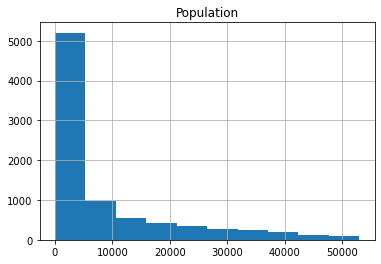

```python
# Population
df_outliers_removed[ ['Population'] ].hist()
```

```
array([[<AxesSubplot:title={'center':'Bandwidth_GB_Year'}>]], dtype=object)
```

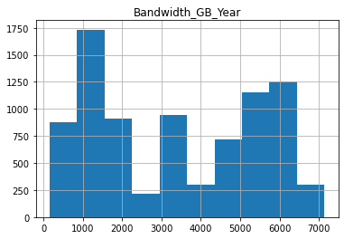

```python
# Bandwidth Use
df_outliers_removed[ ['Bandwidth_GB_Year'] ].hist()
```

```
array([[<AxesSubplot:title={'center':'MonthlyCharge'}>]], dtype=object)
```

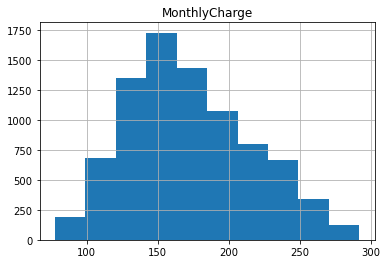

```python
# Monthly Charges
df_outliers_removed[ ['MonthlyCharge'] ].hist()
```

```
array([[<AxesSubplot:title={'center':'Tenure'}>]], dtype=object)
```

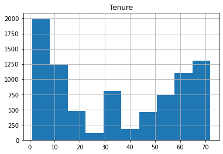

```python
# Tenure
df_outliers_removed[ ['Tenure'] ].hist()
```

```
array([[<AxesSubplot:title={'center':'Age'}>]], dtype=object)
```

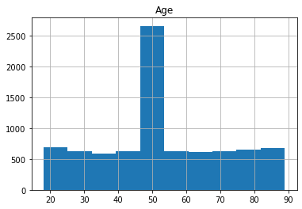

```python
# Age
df_outliers_removed[ ['Age'] ].hist()
```

```
array([[<AxesSubplot:title={'center':'Children'}>]], dtype=object)
```

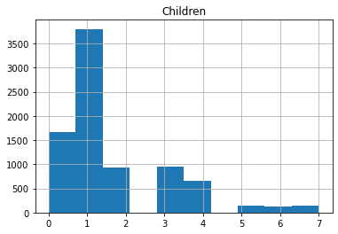

```python
# Amount of Children
df_outliers_removed[ ['Children'] ].hist()
```

```
array([[<AxesSubplot:title={'center':'Income'}>]], dtype=object)
```

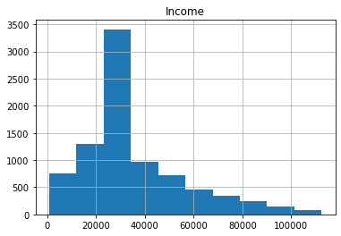

```python
# Income
df_outliers_removed[ ['Income'] ].hist()
```

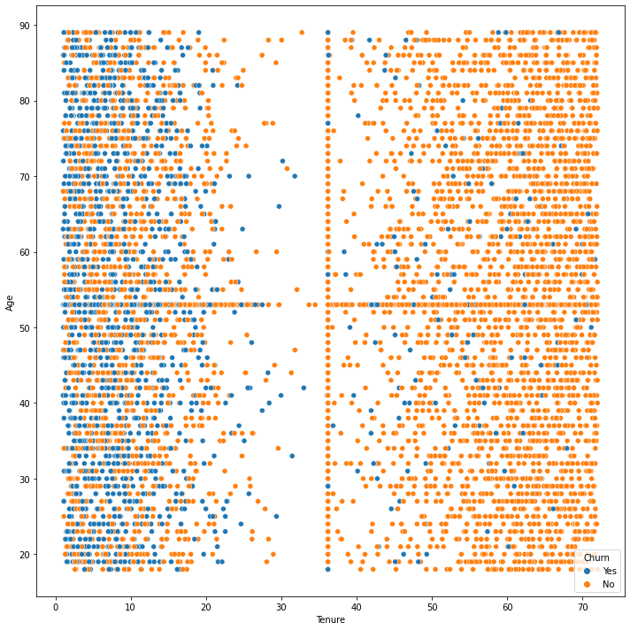

```python
fig, ax = plt.subplots(figsize=(10,10))
sns.scatterplot(data=df_outliers_removed, x='Tenure', y='Age', hue='Churn',
               ax=ax)
plt.tight_layout()
plt.show()
```

> Tenure is a big factor in whether a customer will churn or not. The vast majority of the customers that churn have a tenure shorter than those that dont.

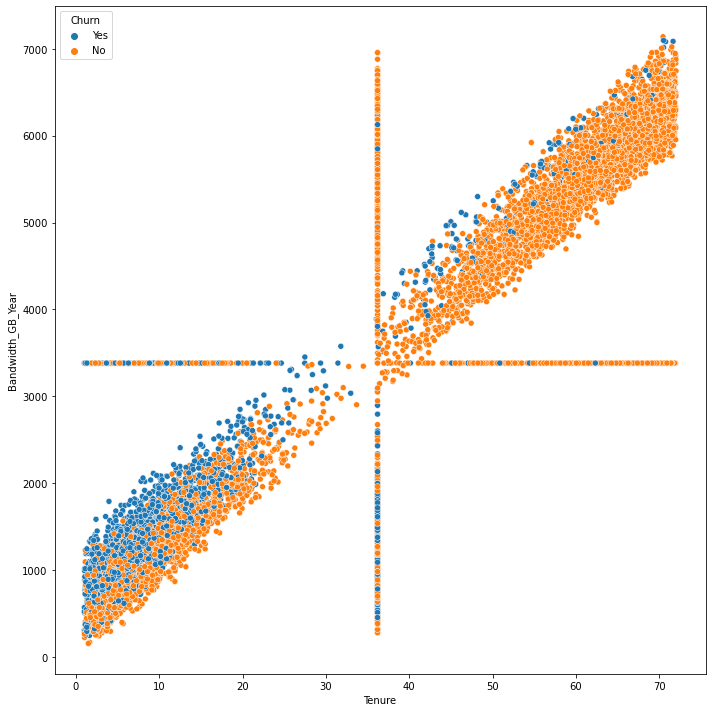

```python
fig, ax = plt.subplots(figsize=(10,10))
sns.scatterplot(data=df_outliers_removed, x='Tenure', y='Bandwidth_GB_Year', hue='Churn',
               ax=ax)
plt.tight_layout()
plt.show()
```

> Bandwidth use is also a big factor in churn. Customers that use more bandwidth have a smaller churn rate than those that use less bandwidth.

## PCA

```python
# PCA works with numeric columns, so we will be using our numeric_col dataframe made earlier
df[numeric_cols].head()
```

|  | Zip | Lat | Lng | Population | Children | Age | Income | Outage_sec_perweek | Email | Contacts | ... | MonthlyCharge | Bandwidth_GB_Year | item1 | item2 | item3 | item4 | item5 | item6 | item7 | item8 |
| --- | --- | --- | --- | --- | --- | --- | --- | --- | --- | --- | --- | --- | --- | --- | --- | --- | --- | --- | --- | --- | --- |
| 0 | 99927 | 56.25100 | -133.37571 | 38 | 1.0 | 68.0 | 28561.990 | 6.972566 | 10 | 0 | ... | 171.449762 | 904.536110 | 5 | 5 | 5 | 3 | 4 | 4 | 3 | 4 |
| 1 | 48661 | 44.32893 | -84.24080 | 10446 | 1.0 | 27.0 | 21704.770 | 12.014541 | 12 | 0 | ... | 242.948015 | 800.982766 | 3 | 4 | 3 | 3 | 4 | 3 | 4 | 4 |
| 2 | 97148 | 45.35589 | -123.24657 | 3735 | 4.0 | 50.0 | 33186.785 | 10.245616 | 9 | 0 | ... | 159.440398 | 2054.706961 | 4 | 4 | 2 | 4 | 4 | 3 | 3 | 3 |
| 3 | 92014 | 32.96687 | -117.24798 | 13863 | 1.0 | 48.0 | 18925.230 | 15.206193 | 15 | 2 | ... | 120.249493 | 2164.579412 | 4 | 4 | 4 | 2 | 5 | 4 | 3 | 3 |
| 4 | 77461 | 29.38012 | -95.80673 | 11352 | 0.0 | 83.0 | 40074.190 | 8.960316 | 16 | 2 | ... | 150.761216 | 271.493436 | 4 | 4 | 4 | 3 | 4 | 4 | 4 | 5 |

5 rows × 22 columns

```python
# Normalizing the data
df_normalized=(df[numeric_cols]-df[numeric_cols].mean())/df[numeric_cols].std()
df_normalized.head()
```

|  | Zip | Lat | Lng | Population | Children | Age | Income | Outage_sec_perweek | Email | Contacts | ... | MonthlyCharge | Bandwidth_GB_Year | item1 | item2 | item3 | item4 | item5 | item6 | item7 | item8 |
| --- | --- | --- | --- | --- | --- | --- | --- | --- | --- | --- | --- | --- | --- | --- | --- | --- | --- | --- | --- | --- | --- |
| 0 | 1.844157 | 3.217249 | -2.810291 | -0.673371 | -0.427057 | 0.821648 | -0.391712 | -0.637694 | -0.666248 | -1.005801 | ... | -0.060610 | -1.202590 | 1.454234 | 1.44485 | 1.471823 | -0.484980 | 0.494819 | 0.486365 | -0.495381 | 0.490359 |
| 1 | -0.017882 | 1.024639 | 0.431623 | 0.047769 | -0.427057 | -1.455693 | -0.668795 | 0.079931 | -0.005288 | -1.005801 | ... | 1.589269 | -1.252550 | -0.472925 | 0.47833 | -0.473746 | -0.484980 | 0.494819 | -0.481141 | 0.476907 | 0.490359 |
| 2 | 1.743220 | 1.213510 | -2.141972 | -0.417217 | 1.130598 | -0.178160 | -0.204835 | -0.171841 | -0.996729 | -1.005801 | ... | -0.337735 | -0.647681 | 0.490655 | 0.47833 | -1.446530 | 0.489854 | 0.494819 | -0.481141 | -0.495381 | -0.481804 |
| 3 | 1.556748 | -1.064978 | -1.746186 | 0.284523 | -0.427057 | -0.289250 | -0.781109 | 0.534199 | 0.986153 | 1.017537 | ... | -1.242096 | -0.594672 | 0.490655 | 0.47833 | 0.499038 | -1.459813 | 1.470601 | 0.486365 | -0.495381 | -0.481804 |
| 4 | 1.028166 | -1.724623 | -0.331496 | 0.110543 | -0.946276 | 1.654821 | 0.073468 | -0.354778 | 1.316634 | 1.017537 | ... | -0.538014 | -1.508006 | 0.490655 | 0.47833 | 0.499038 | -0.484980 | 0.494819 | 0.486365 | 0.476907 | 1.462523 |

5 rows × 22 columns

```python
# Setting up PCA
pca = PCA(n_components=df[numeric_cols].shape[1])
```

```python
# Calling this PCA application on the data set to create a new data set
# that converts the data set of 22 variables into a data set of 22 components:
pca.fit(df_normalized)
df_pca = pd.DataFrame(pca.transform(df_normalized))
df_pca.head()
```

|  | 0 | 1 | 2 | 3 | 4 | 5 | 6 | 7 | 8 | 9 | ... | 12 | 13 | 14 | 15 | 16 | 17 | 18 | 19 | 20 | 21 |
| --- | --- | --- | --- | --- | --- | --- | --- | --- | --- | --- | --- | --- | --- | --- | --- | --- | --- | --- | --- | --- | --- |
| 0 | 1.847514 | 3.583851 | 0.435058 | 2.097731 | -2.842824 | -0.620718 | -0.173827 | 0.735651 | -1.267139 | -0.156637 | ... | -0.303567 | 1.170850 | 1.212830 | -0.736535 | 0.288603 | -0.193391 | 0.019699 | 0.011986 | -0.051223 | 0.334044 |
| 1 | -0.201112 | 0.634028 | -1.601856 | 0.512070 | -0.787821 | 1.322871 | 0.875375 | -0.376283 | -1.136143 | -0.871706 | ... | -1.188820 | 0.107209 | 1.047580 | 0.854163 | -0.427401 | 0.211625 | -0.455412 | -0.695603 | -0.038693 | -0.409459 |
| 2 | -0.742125 | 2.823076 | 0.568866 | 0.422908 | -1.435014 | -0.412658 | 1.542519 | 0.705526 | -0.747523 | -0.000131 | ... | -0.014399 | 0.463398 | 0.166903 | -0.372749 | -0.301748 | 0.969095 | -1.337367 | 0.426687 | 0.025613 | 0.183448 |
| 3 | -0.013179 | 2.243486 | 0.516422 | 2.380670 | 1.122676 | -0.149227 | -0.906808 | -1.027344 | -0.142558 | 0.426064 | ... | 1.238244 | -0.487080 | -0.658001 | 0.106968 | 0.764911 | 0.386146 | 0.200662 | 0.000863 | 0.121214 | 0.262107 |
| 4 | 1.311702 | 1.790126 | -1.153209 | 0.867029 | 1.711710 | -0.200721 | -1.666475 | 1.005335 | -0.327729 | 1.430741 | ... | 0.207582 | -1.651149 | 0.163330 | 0.300685 | -0.081085 | 0.127024 | 0.201639 | -0.084564 | -0.053154 | -0.289412 |

5 rows × 22 columns

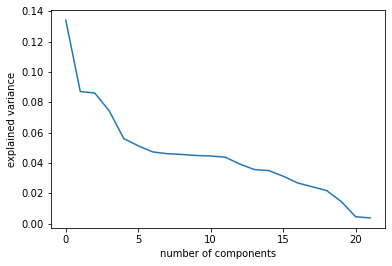

```python
# Scree Plot
plt.plot(pca.explained_variance_ratio_)
plt.xlabel('number of components')
plt.ylabel('explained variance')
plt.show()
```

```python
for pc, var in zip(df_pca, np.cumsum(pca.explained_variance_ratio_)):
    print(pc, var)
```

```
0 0.13403040535405364
1 0.22112024319918
2 0.3072299522647064
3 0.38158740994533813
4 0.4376889545193223
5 0.4890664311084467
6 0.5364158256227414
7 0.5825989445677479
8 0.6282795221619547
9 0.6732905410226687
10 0.7179473053996724
11 0.7618441214504037
12 0.8012307024632452
13 0.8369980647775255
14 0.8720569868160788
15 0.9034375035254611
16 0.9303374229445527
17 0.9547733901116912
18 0.9766705523548185
19 0.9914102560189552
20 0.996090645577639
21 1.0000000000000002
```

```python
# Setting up Eigenvalues
cov_matrix = np.dot(df_pca.T, df_pca) / df[numeric_cols].shape[0]
eigenvalues = [np.dot(eigenvector.T, np.dot(cov_matrix, eigenvector)) for eigenvector in pca.components_]
```

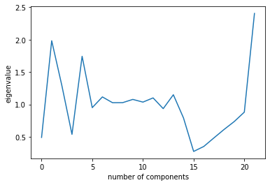

```python
# Eigenvalues Plot
plt.plot(eigenvalues)
plt.xlabel('number of components')
plt.ylabel('eigenvalue')
plt.show()
```

> This Eigenvalues graph shows us which of the components have the most effect

```python
# Values of the above eigenvalue plot
eigenvalues
```

```
[0.4904025133757227,
 1.9831916367808045,
 1.2928658161759334,
 0.5377142070453219,
 1.7430662141182924,
 0.9503978861481834,
 1.1157484853452713,
 1.0266129734307983,
 1.0273379761446622,
 1.0773329481453409,
 1.0358585626745336,
 1.1005112892479907,
 0.9351851778025991,
 1.1494802461521085,
 0.7911402911483355,
 0.2741318923357062,
 0.35071949995575225,
 0.4828343474966571,
 0.6129411968118513,
 0.7348486864717851,
 0.8807573603631088,
 2.4047207928294903]
```

```python
# Output the loadings for the components
loadings = pd.DataFrame(pca.components_.T,
index=df[numeric_cols].columns)
loadings
```

|  | 0 | 1 | 2 | 3 | 4 | 5 | 6 | 7 | 8 | 9 | ... | 12 | 13 | 14 | 15 | 16 | 17 | 18 | 19 | 20 | 21 |
| --- | --- | --- | --- | --- | --- | --- | --- | --- | --- | --- | --- | --- | --- | --- | --- | --- | --- | --- | --- | --- | --- |
| Zip | -0.018962 | 0.597723 | 0.367241 | 0.045995 | 0.025766 | 0.007902 | 0.008536 | -0.002460 | 0.002844 | 0.020329 | ... | -0.016484 | -0.091670 | -0.076054 | -0.013332 | -0.012350 | -0.002827 | -0.003856 | 0.011561 | 0.037961 | -0.698086 |
| Lat | -0.001264 | 0.036428 | -0.003831 | -0.003650 | -0.701846 | -0.074731 | -0.066959 | -0.067855 | -0.008787 | 0.026958 | ... | 0.035123 | 0.512331 | 0.456922 | 0.039991 | 0.029516 | -0.006487 | 0.013364 | -0.007460 | 0.007600 | -0.117638 |
| Lng | 0.016911 | -0.601005 | -0.366875 | -0.043686 | 0.060851 | 0.002944 | 0.000739 | 0.018275 | -0.003217 | -0.020217 | ... | 0.004556 | -0.019458 | -0.019365 | 0.002429 | 0.006440 | 0.011549 | -0.006854 | -0.008609 | 0.039884 | -0.703328 |
| Population | -0.002824 | 0.051655 | 0.039349 | 0.023295 | 0.674777 | 0.088815 | 0.058712 | 0.058223 | 0.072261 | -0.091062 | ... | 0.051182 | 0.583536 | 0.403912 | 0.051286 | 0.001240 | -0.000604 | 0.000315 | -0.006216 | 0.001066 | -0.031023 |
| Children | 0.000765 | -0.028134 | -0.019290 | 0.006568 | -0.051764 | 0.004924 | 0.595171 | -0.005556 | 0.109244 | 0.494196 | ... | 0.018504 | -0.000414 | 0.035559 | -0.035166 | -0.017559 | 0.011572 | 0.018793 | -0.007898 | -0.018365 | 0.000596 |
| Age | 0.005031 | 0.005989 | -0.011956 | -0.017238 | 0.022937 | -0.041579 | -0.486896 | 0.435694 | -0.061781 | 0.368169 | ... | 0.111048 | 0.050582 | -0.039413 | 0.010709 | -0.000952 | -0.012257 | 0.008553 | 0.015943 | 0.021566 | 0.002083 |
| Income | -0.000865 | -0.003241 | 0.007037 | 0.024023 | -0.059103 | -0.016118 | 0.189761 | 0.279593 | 0.828547 | 0.086189 | ... | -0.070946 | -0.023634 | -0.004625 | -0.060529 | -0.005682 | 0.000679 | 0.013843 | 0.004888 | 0.001307 | 0.001633 |
| Outage_sec_perweek | -0.013211 | -0.004121 | 0.018783 | -0.047269 | -0.102496 | 0.696174 | 0.043868 | 0.026441 | 0.026561 | -0.016155 | ... | 0.689960 | 0.030457 | -0.125374 | 0.010382 | -0.012851 | -0.016354 | 0.010004 | -0.004286 | 0.000890 | -0.000604 |
| Email | 0.008789 | 0.000776 | -0.023553 | -0.004935 | 0.142160 | 0.090877 | -0.145591 | -0.545825 | -0.041884 | 0.691431 | ... | -0.042715 | -0.013874 | 0.077390 | -0.015755 | -0.015180 | 0.006557 | -0.016263 | 0.001075 | 0.005581 | -0.002764 |
| Contacts | -0.008457 | -0.009614 | -0.001494 | -0.011417 | 0.025234 | -0.002548 | -0.509535 | 0.179303 | 0.279789 | 0.200637 | ... | 0.015125 | -0.029127 | 0.026361 | -0.036760 | -0.004051 | -0.026222 | 0.020868 | -0.000644 | -0.002790 | 0.002234 |
| Yearly_equip_failure | -0.007854 | 0.001318 | 0.019810 | 0.008130 | -0.011519 | 0.055041 | 0.266646 | 0.623891 | -0.454273 | 0.273838 | ... | -0.116899 | 0.017406 | 0.050615 | 0.006977 | -0.013799 | -0.000799 | 0.007224 | -0.021312 | -0.002546 | 0.002842 |
| Tenure | -0.010557 | -0.362539 | 0.600117 | -0.069454 | -0.002595 | -0.058316 | -0.017625 | -0.011722 | -0.004672 | 0.015077 | ... | 0.038511 | 0.005286 | 0.006234 | -0.009569 | 0.007921 | -0.012186 | 0.006556 | 0.004981 | -0.703834 | -0.040373 |
| MonthlyCharge | -0.000373 | -0.032841 | 0.030519 | -0.025683 | -0.079399 | 0.692293 | -0.090800 | 0.008793 | 0.022579 | -0.055171 | ... | -0.683697 | -0.003792 | 0.054991 | 0.010218 | -0.014661 | 0.000472 | 0.021251 | -0.012869 | -0.048304 | 0.000063 |
| Bandwidth_GB_Year | -0.012470 | -0.363222 | 0.601690 | -0.071704 | -0.009351 | -0.010265 | 0.006328 | -0.017185 | 0.000950 | 0.009140 | ... | -0.011229 | -0.001100 | 0.016074 | 0.002781 | 0.003704 | -0.001646 | -0.007770 | 0.007206 | 0.705717 | 0.038464 |
| item1 | 0.458917 | -0.031599 | 0.017059 | 0.279271 | -0.016686 | 0.029547 | 0.003466 | 0.009295 | -0.015839 | 0.000707 | ... | -0.006291 | 0.057746 | -0.043229 | -0.117406 | -0.046745 | 0.024174 | -0.239401 | 0.793112 | -0.003088 | 0.002241 |
| item2 | 0.433920 | -0.021631 | 0.036046 | 0.281915 | -0.020063 | 0.015734 | -0.019768 | 0.007713 | 0.002086 | 0.001755 | ... | -0.000257 | 0.076214 | -0.079837 | -0.170238 | -0.067158 | 0.068154 | -0.592018 | -0.572988 | -0.003184 | 0.003369 |
| item3 | 0.400822 | -0.030113 | 0.021208 | 0.280276 | -0.002324 | -0.010926 | -0.004122 | -0.031107 | -0.030892 | -0.008330 | ... | -0.010229 | 0.115524 | -0.133059 | -0.248481 | -0.147980 | -0.392169 | 0.675918 | -0.177146 | 0.014838 | -0.005332 |
| item4 | 0.145480 | 0.056611 | -0.022662 | -0.566174 | -0.001972 | -0.032552 | -0.004024 | -0.004100 | -0.020913 | -0.022476 | ... | -0.020921 | 0.146691 | -0.106456 | -0.475927 | -0.446066 | 0.431244 | 0.085514 | 0.017923 | 0.001599 | 0.001762 |
| item5 | -0.175341 | -0.064905 | 0.035936 | 0.585081 | -0.010339 | 0.025235 | -0.039041 | 0.003129 | -0.007019 | -0.009509 | ... | 0.040987 | -0.086413 | 0.098093 | 0.061128 | -0.209886 | 0.694746 | 0.260449 | -0.042863 | -0.003093 | 0.003050 |
| item6 | 0.404667 | 0.036587 | 0.008909 | -0.181538 | 0.014993 | 0.008023 | 0.005434 | 0.005867 | 0.007728 | 0.019818 | ... | -0.005523 | 0.024344 | -0.061971 | 0.059620 | 0.756876 | 0.405172 | 0.226970 | -0.064903 | 0.001429 | -0.000486 |
| item7 | 0.358085 | 0.019791 | 0.008218 | -0.180023 | -0.016392 | -0.036076 | 0.013409 | -0.002578 | 0.054986 | 0.031780 | ... | -0.026549 | 0.069817 | -0.157942 | 0.806201 | -0.375413 | 0.067968 | 0.064782 | -0.041230 | -0.006652 | -0.001889 |
| item8 | 0.308589 | 0.024711 | -0.003619 | -0.131005 | 0.042996 | 0.037578 | -0.008846 | 0.043926 | -0.004943 | -0.062822 | ... | 0.119731 | -0.570830 | 0.717708 | -0.018580 | -0.110818 | -0.043914 | 0.047040 | -0.042988 | -0.002863 | -0.002202 |

22 rows × 22 columns

> Many of the survey responses have a large affect and would be considered principal components. Respectfulness, Timely Responses, Active Listening, etc. These would have an affect because they directly affect the customer. If a customer is being treated good and respecfully, they would likely want to continue business.

> An organization can benefit from the results of PCA because they can find specifically what factors contribute to the business problem they want to solve. For example, they can find what factors greatly correlate and contribute to customer churn rate, and the organization can work on fixing those issues to lower the churn rate.